# Lab08 - Categorical explanatory variables

Jarad Niemi

2017-03-28

To follow along, use the lab08 code and make sure the following packages are installed:

- Sleuth3
- readr

You can use the following code to perform the installation:

```r
install.packages(c("Sleuth3","readr"))
```

Now load the packages

```r
library("dplyr")
```

```r
library("ggplot2")
library("Sleuth3")
```

## Overview

Categorical variables in R are represented either by a

- character
- factor

A factor is a special character variable that

- has an underlying numerical representation,
- a lookup table to find the values, and
- an inherent ordering.

## Characters

Let’s create a test data set.

```r
n <- 12
test <- data.frame(y = rnorm(n))
test$char <- rep(c("a","b","A","B"), each=3)
```

If you look at the type of `char`, it will be a character (vector).

```r
str(test$char)
```

```
##  chr [1:12] "a" "a" "a" "b" "b" "b" "A" "A" "A" ...
```

If you try to run a `summary()`, you won’t get much.

```r
summary(test)
```

```
##        y               char
##  Min.   :-1.0394   Length:12
##  1st Qu.:-0.4714   Class :character
##  Median : 0.6168   Mode  :character
##  Mean   : 0.3353
##  3rd Qu.: 0.9759
##  Max.   : 1.5578
```

```r
summary(test$char)
```

```
##    Length     Class      Mode
##        12 character character
```

Instead, you want to use the `table()` function.

```r
table(test$char)
```

```
##
## a A b B
## 3 3 3 3
```

When you use the `readr::read_csv()` function to read in data, character columns are left as characters. First we need to write the csv file.

```r
write.csv(test, file = "test.csv", row.names = FALSE)
```

Now let’s read it in.

```r
test2 <- readr::read_csv("test.csv")
summary(test2)
```

```
##        y               char
##  Min.   :-1.0394   Length:12
##  1st Qu.:-0.4714   Class :character
##  Median : 0.6168   Mode  :character
##  Mean   : 0.3353
##  3rd Qu.: 0.9759
##  Max.   : 1.5578
```

#### `readr::read_csv()` Activity

Use the `case0501` data set from the `Sleuth3` package to practice writing to a csv file and reading from the csv file. Verify that Diet is read in as a character vector.

```r
write.csv(Sleuth3::case0501, file = "case0501.csv", row.names = FALSE)
tmp <- readr::read_csv("case0501.csv")
summary(tmp)
```

```
##     Lifetime        Diet
##  Min.   : 6.4   Length:349
##  1st Qu.:31.8   Class :character
##  Median :39.5   Mode  :character
##  Mean   :38.8
##  3rd Qu.:46.9
##  Max.   :54.6
```

## Factors

When you read in data using the `read.csv()` function, all character vectors will automatically be converted to factor vectors.

```r
case0501 <- read.csv(file = "case0501.csv") # We are overwriting the Sleuth3::case0501 data.frame
```

Note that `Diet` is a factor.

```r
str(case0501$Diet)
```

```
##  Factor w/ 6 levels "lopro","N/N85",..: 5 5 5 5 5 5 5 5 5 5 ...
```

Although printing out this variable makes it look like a character:

```r
case0501$Diet
```

```
##   [1] NP    NP    NP    NP    NP    NP    NP    NP    NP    NP    NP
##  [12] NP    NP    NP    NP    NP    NP    NP    NP    NP    NP    NP
##  [23] NP    NP    NP    NP    NP    NP    NP    NP    NP    NP    NP
##  [34] NP    NP    NP    NP    NP    NP    NP    NP    NP    NP    NP
##  [45] NP    NP    NP    NP    NP    N/N85 N/N85 N/N85 N/N85 N/N85 N/N85
##  [56] N/N85 N/N85 N/N85 N/N85 N/N85 N/N85 N/N85 N/N85 N/N85 N/N85 N/N85
##  [67] N/N85 N/N85 N/N85 N/N85 N/N85 N/N85 N/N85 N/N85 N/N85 N/N85 N/N85
##  [78] N/N85 N/N85 N/N85 N/N85 N/N85 N/N85 N/N85 N/N85 N/N85 N/N85 N/N85
##  [89] N/N85 N/N85 N/N85 N/N85 N/N85 N/N85 N/N85 N/N85 N/N85 N/N85 N/N85
## [100] N/N85 N/N85 N/N85 N/N85 N/N85 N/N85 N/N85 lopro lopro lopro lopro
## [111] lopro lopro lopro lopro lopro lopro lopro lopro lopro lopro lopro
## [122] lopro lopro lopro lopro lopro lopro lopro lopro lopro lopro lopro
## [133] lopro lopro lopro lopro lopro lopro lopro lopro lopro lopro lopro
## [144] lopro lopro lopro lopro lopro lopro lopro lopro lopro lopro lopro
## [155] lopro lopro lopro lopro lopro lopro lopro lopro N/R50 N/R50 N/R50
```

[output cut: 18 more lines]

There is actually an internal representation via integers:

```r
as.numeric(case0501$Diet)
```

```
##   [1] 5 5 5 5 5 5 5 5 5 5 5 5 5 5 5 5 5 5 5 5 5 5 5 5 5 5 5 5 5 5 5 5 5 5 5
##  [36] 5 5 5 5 5 5 5 5 5 5 5 5 5 5 2 2 2 2 2 2 2 2 2 2 2 2 2 2 2 2 2 2 2 2 2
##  [71] 2 2 2 2 2 2 2 2 2 2 2 2 2 2 2 2 2 2 2 2 2 2 2 2 2 2 2 2 2 2 2 2 2 2 2
## [106] 2 1 1 1 1 1 1 1 1 1 1 1 1 1 1 1 1 1 1 1 1 1 1 1 1 1 1 1 1 1 1 1 1 1 1
## [141] 1 1 1 1 1 1 1 1 1 1 1 1 1 1 1 1 1 1 1 1 1 1 4 4 4 4 4 4 4 4 4 4 4 4 4
## [176] 4 4 4 4 4 4 4 4 4 4 4 4 4 4 4 4 4 4 4 4 4 4 4 4 4 4 4 4 4 4 4 4 4 4 4
## [211] 4 4 4 4 4 4 4 4 4 4 4 4 4 4 4 4 4 4 4 4 4 4 4 6 6 6 6 6 6 6 6 6 6 6 6
## [246] 6 6 6 6 6 6 6 6 6 6 6 6 6 6 6 6 6 6 6 6 6 6 6 6 6 6 6 6 6 6 6 6 6 6 6
## [281] 6 6 6 6 6 6 6 6 6 3 3 3 3 3 3 3 3 3 3 3 3 3 3 3 3 3 3 3 3 3 3 3 3 3 3
## [316] 3 3 3 3 3 3 3 3 3 3 3 3 3 3 3 3 3 3 3 3 3 3 3 3 3 3 3 3 3 3 3 3 3 3
```

This representation can be accessed using `levels()`:

```r
nlevels(case0501$Diet)
```

```
## [1] 6
```

```r
levels(case0501$Diet)
```

```
## [1] "lopro" "N/N85" "N/R40" "N/R50" "NP"    "R/R50"
```

The ordering here is alphabetical.

When you run `summary()` or `table()`, R uses this ordering for displaying results:

```r
summary(case0501$Diet)
```

```
## lopro N/N85 N/R40 N/R50    NP R/R50
##    56    57    60    71    49    56
```

```r
table(  case0501$Diet)
```

```
##
## lopro N/N85 N/R40 N/R50    NP R/R50
##    56    57    60    71    49    56
```

You can convert factors into characters

```r
case0501$Diet_char <- as.character(case0501$Diet)
str(case0501)
```

```
## 'data.frame':    349 obs. of  3 variables:
##  $ Lifetime : num  35.5 35.4 34.9 34.8 33.8 33.5 32.6 32.4 31.8 31.6 ...
##  $ Diet     : Factor w/ 6 levels "lopro","N/N85",..: 5 5 5 5 5 5 5 5 5 5 ...
##  $ Diet_char: chr  "NP" "NP" "NP" "NP" ...
```

and characters back to factors

```r
case0501$Diet_fact <- as.factor(case0501$Diet_char)
str(case0501)
```

```
## 'data.frame':    349 obs. of  4 variables:
##  $ Lifetime : num  35.5 35.4 34.9 34.8 33.8 33.5 32.6 32.4 31.8 31.6 ...
##  $ Diet     : Factor w/ 6 levels "lopro","N/N85",..: 5 5 5 5 5 5 5 5 5 5 ...
##  $ Diet_char: chr  "NP" "NP" "NP" "NP" ...
##  $ Diet_fact: Factor w/ 6 levels "lopro","N/N85",..: 5 5 5 5 5 5 5 5 5 5 ...
```

```r
all.equal(case0501$Diet, case0501$Diet_fact)
```

```
## [1] TRUE
```

#### Activity

Practice reading and writing files using `read.csv()` and `readr::read_csv()`. Specifically, do the following

1. Write `case0501` to a csv using `write.csv()`. Do not write the rownames.
2. Read in the created csv file using both `read.csv()` and `readr::read_csv()`. What differences are there?
3. Use the help file for `read.csv()` to read in the data without converting Diet to a factor.
4. Convert Diet in the `readr::read_csv()` function to a factor.
5. Write `case0501` to a csv using `readr::write_csv()` and see what the differences are from the first step.

Here is what I would do

```r
# Write csv file
write.csv(case0501, file = "tmp.csv", row.names = FALSE)

# Read csv file
d  <- read.csv("tmp.csv")
d2 <- readr::read_csv("tmp.csv")

# Don't convert to factor when reading in
d  <- read.csv("tmp.csv", stringsAsFactors = FALSE)

# Convert Diet into a factor
d2 <- d2 %>%
  mutate(Diet = factor(Diet))

readr::write_csv(case0501, path = "tmp2.csv") # Automatically doesn't include rownames
```

Depending on your application, you may decide that `read.csv()` is what you typically want to use or you may decide the `readr::read_csv()` is what you typically want to use.

### Creating factors

We have already seen that you can create factors using the `as.factor()` function. But sometimes we want a bit more control. In particular, we may be interested in affecting the ordering of the levels of the factor.

To adjust the ordering of the levels of the factor, use the `levels` argument of the `factor()` function.

```r
newDiet = factor(case0501$Diet,
                 levels = c("NP","N/N85","N/R40","N/R50","lopro","R/R50"))
table(newDiet) # compare to table(case0501$Diet)
```

```
## newDiet
##    NP N/N85 N/R40 N/R50 lopro R/R50
##    49    57    60    71    56    56
```

## Using categorical variables in a regression

Let’s make sure we have the correct `data.frame` for the following.

```r
case0501 <- Sleuth3::case0501 %>%
  mutate(Diet_char = as.character(Diet),
         Diet_fact = as.factor(Diet_char))
```

### Using a character vector as the explanatory variable

Let’s perform the Lifetime-Diet ``regression’’ using the character vector for Diet.

```r
m <- lm(Lifetime ~ Diet_char, data = case0501)
summary(m)
```

```
##
## Call:
## lm(formula = Lifetime ~ Diet_char, data = case0501)
##
## Residuals:
##      Min       1Q   Median       3Q      Max
## -25.5167  -3.3857   0.8143   5.1833  10.0143
##
## Coefficients:
##                Estimate Std. Error t value Pr(>|t|)
## (Intercept)     39.6857     0.8924  44.470  < 2e-16 ***
## Diet_charN/N85  -6.9945     1.2565  -5.567 5.25e-08 ***
## Diet_charN/R40   5.4310     1.2409   4.377 1.60e-05 ***
## Diet_charN/R50   2.6115     1.1936   2.188   0.0293 *
## Diet_charNP    -12.2837     1.3064  -9.403  < 2e-16 ***
## Diet_charR/R50   3.2000     1.2621   2.536   0.0117 *
## ---
## Signif. codes:  0 '***' 0.001 '**' 0.01 '*' 0.05 '.' 0.1 ' ' 1
##
## Residual standard error: 6.678 on 343 degrees of freedom
## Multiple R-squared:  0.4543, Adjusted R-squared:  0.4463
## F-statistic:  57.1 on 5 and 343 DF,  p-value: < 2.2e-16
```

Notice that it automatically constructed all our indicator variables. It automatically chose the lopro diet as the reference level (because it came first alphabetically).

If you leave Diet as a character vector then you cannot control the reference level.

### Using a factor vector as the explanatory variable

Let’s perform the Lifetime-Diet ``regression’’ using the factor vector for Diet.

```r
m <- lm(Lifetime ~ Diet_fact, data = case0501)
summary(m)
```

```
##
## Call:
## lm(formula = Lifetime ~ Diet_fact, data = case0501)
##
## Residuals:
##      Min       1Q   Median       3Q      Max
## -25.5167  -3.3857   0.8143   5.1833  10.0143
##
## Coefficients:
##                Estimate Std. Error t value Pr(>|t|)
## (Intercept)     39.6857     0.8924  44.470  < 2e-16 ***
## Diet_factN/N85  -6.9945     1.2565  -5.567 5.25e-08 ***
## Diet_factN/R40   5.4310     1.2409   4.377 1.60e-05 ***
## Diet_factN/R50   2.6115     1.1936   2.188   0.0293 *
## Diet_factNP    -12.2837     1.3064  -9.403  < 2e-16 ***
## Diet_factR/R50   3.2000     1.2621   2.536   0.0117 *
## ---
## Signif. codes:  0 '***' 0.001 '**' 0.01 '*' 0.05 '.' 0.1 ' ' 1
##
## Residual standard error: 6.678 on 343 degrees of freedom
## Multiple R-squared:  0.4543, Adjusted R-squared:  0.4463
## F-statistic:  57.1 on 5 and 343 DF,  p-value: < 2.2e-16
```

These results are identical to the results using the character vector.

### Adjusting the reference level

Now suppose you want to run the regression using N/N85 (normal diet) as the reference level. Do this using the `relevel()` function and its `ref` argument.

```r
case0501$Diet_fact <- relevel(case0501$Diet_fact, ref = "N/N85")
table(case0501$Diet_fact)
```

```
##
## N/N85 lopro N/R40 N/R50    NP R/R50
##    57    56    60    71    49    56
```

Notice how N/N85 is now the first level.

Now when you run the regression the reference level will be N/N85.

```r
m <- lm(Lifetime ~ Diet_fact, data = case0501)
summary(m)
```

```
##
## Call:
## lm(formula = Lifetime ~ Diet_fact, data = case0501)
##
## Residuals:
##      Min       1Q   Median       3Q      Max
## -25.5167  -3.3857   0.8143   5.1833  10.0143
##
## Coefficients:
##                Estimate Std. Error t value Pr(>|t|)
## (Intercept)     32.6912     0.8846  36.958  < 2e-16 ***
## Diet_factlopro   6.9945     1.2565   5.567 5.25e-08 ***
## Diet_factN/R40  12.4254     1.2352  10.059  < 2e-16 ***
## Diet_factN/R50   9.6060     1.1877   8.088 1.06e-14 ***
## Diet_factNP     -5.2892     1.3010  -4.065 5.95e-05 ***
## Diet_factR/R50  10.1945     1.2565   8.113 8.88e-15 ***
## ---
## Signif. codes:  0 '***' 0.001 '**' 0.01 '*' 0.05 '.' 0.1 ' ' 1
##
## Residual standard error: 6.678 on 343 degrees of freedom
## Multiple R-squared:  0.4543, Adjusted R-squared:  0.4463
## F-statistic:  57.1 on 5 and 343 DF,  p-value: < 2.2e-16
```

The authors of the `Sleuth3` package had already made N/N85 the reference level so if you run the regression with the original data, N/N85 will be the reference level.

```r
m <- lm(Lifetime ~ Diet, data = Sleuth3::case0501)
summary(m)
```

```
##
## Call:
## lm(formula = Lifetime ~ Diet, data = Sleuth3::case0501)
##
## Residuals:
##      Min       1Q   Median       3Q      Max
## -25.5167  -3.3857   0.8143   5.1833  10.0143
##
## Coefficients:
##             Estimate Std. Error t value Pr(>|t|)
## (Intercept)  32.6912     0.8846  36.958  < 2e-16 ***
## DietN/R40    12.4254     1.2352  10.059  < 2e-16 ***
## DietN/R50     9.6060     1.1877   8.088 1.06e-14 ***
## DietNP       -5.2892     1.3010  -4.065 5.95e-05 ***
## DietR/R50    10.1945     1.2565   8.113 8.88e-15 ***
## Dietlopro     6.9945     1.2565   5.567 5.25e-08 ***
## ---
## Signif. codes:  0 '***' 0.001 '**' 0.01 '*' 0.05 '.' 0.1 ' ' 1
##
## Residual standard error: 6.678 on 343 degrees of freedom
## Multiple R-squared:  0.4543, Adjusted R-squared:  0.4463
## F-statistic:  57.1 on 5 and 343 DF,  p-value: < 2.2e-16
```

#### Check the regression activity

Verify that the regression is correct by constructing indicator variables for the non-reference level explanatory variable levels and running the regression to reproduce the results above.

```r
d <- case0501 %>%
  mutate(X1 = Diet == "N/R40",
         X2 = Diet == "N/R50",
         X3 = Diet == "NP",
         X4 = Diet == "R/R50",
         X5 = Diet == "lopro")

m2 <- lm(Lifetime ~ X1+X2+X3+X4+X5, data = d)
summary(m2)
```

```
##
## Call:
## lm(formula = Lifetime ~ X1 + X2 + X3 + X4 + X5, data = d)
##
## Residuals:
##      Min       1Q   Median       3Q      Max
## -25.5167  -3.3857   0.8143   5.1833  10.0143
##
## Coefficients:
##             Estimate Std. Error t value Pr(>|t|)
## (Intercept)  32.6912     0.8846  36.958  < 2e-16 ***
## X1TRUE       12.4254     1.2352  10.059  < 2e-16 ***
## X2TRUE        9.6060     1.1877   8.088 1.06e-14 ***
## X3TRUE       -5.2892     1.3010  -4.065 5.95e-05 ***
## X4TRUE       10.1945     1.2565   8.113 8.88e-15 ***
## X5TRUE        6.9945     1.2565   5.567 5.25e-08 ***
## ---
## Signif. codes:  0 '***' 0.001 '**' 0.01 '*' 0.05 '.' 0.1 ' ' 1
##
## Residual standard error: 6.678 on 343 degrees of freedom
## Multiple R-squared:  0.4543, Adjusted R-squared:  0.4463
## F-statistic:  57.1 on 5 and 343 DF,  p-value: < 2.2e-16
```

#### Data analysis activity

Use the `ex0518` `data.frame` from the `Sleuth3` package.

Adjust the order of the levels of treatment to have increasing CPFA and make “Control” the reference level. Create a plot of protein versus treatment. Run a regression of protein on treatment to determine which CPFA levels have a mean protein level that is significantly different from the control. Look at the diagnostic plots to determine if there are any clear violations of model assumptions.

Get the data and adjust the levels of treatment.

```r
d <- Sleuth3::ex0518 %>%
  mutate(Treatment = factor(Treatment,
                            levels = c("Control","CPFA50","CPFA150",
                                       "CPFA300","CPFA450","CPFA600")))
```

Now create the plot.

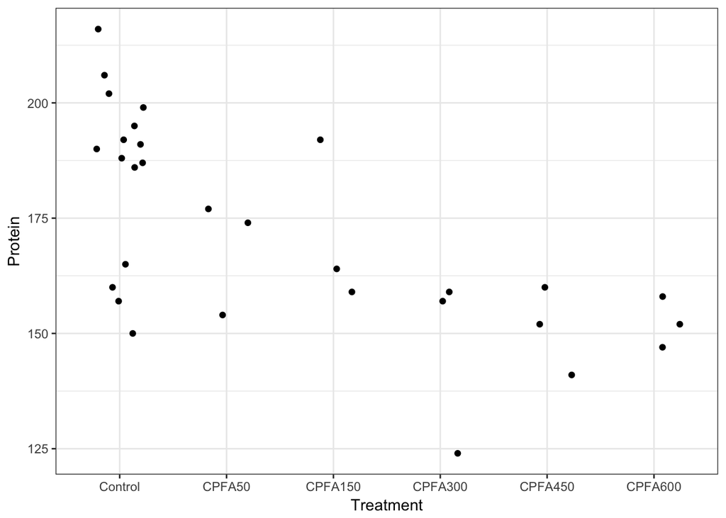

```r
library(ggplot2)
ggplot(d, aes(Treatment, Protein)) +
  geom_jitter(height=0, width=.25) +
  theme_bw()
```

Notice that the ordering on the x-axis is according to the ordering of the levels of treatment.

Now run the regression.

```r
m <- lm(Protein ~ Treatment, data = d)
summary(m)
```

```
##
## Call:
## lm(formula = Protein ~ Treatment, data = d)
##
## Residuals:
##     Min      1Q  Median      3Q     Max
## -35.600  -9.417   3.400   9.300  30.400
##
## Coefficients:
##                  Estimate Std. Error t value Pr(>|t|)
## (Intercept)       185.600      4.441  41.792  < 2e-16 ***
## TreatmentCPFA50   -17.267     10.878  -1.587  0.12554
## TreatmentCPFA150  -13.933     10.878  -1.281  0.21249
## TreatmentCPFA300  -38.933     10.878  -3.579  0.00151 **
## TreatmentCPFA450  -34.600     10.878  -3.181  0.00402 **
## TreatmentCPFA600  -33.267     10.878  -3.058  0.00540 **
## ---
## Signif. codes:  0 '***' 0.001 '**' 0.01 '*' 0.05 '.' 0.1 ' ' 1
##
## Residual standard error: 17.2 on 24 degrees of freedom
## Multiple R-squared:  0.5043, Adjusted R-squared:  0.401
## F-statistic: 4.883 on 5 and 24 DF,  p-value: 0.003196
```

Based on this regression analysis, CPFA levels at 300 or above have significantly different mean protein levels.

Finally look at the diagnostic plots.

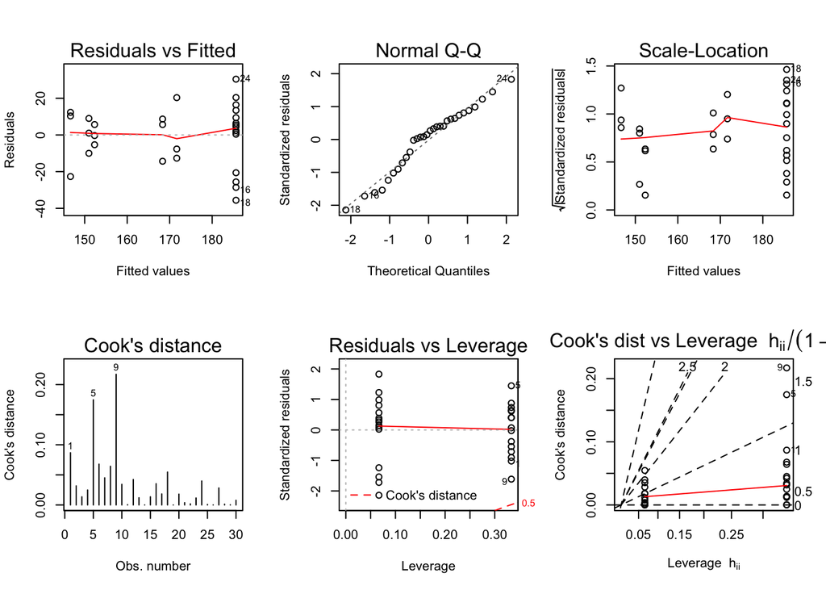

```r
opar = par(mfrow=c(2,3))
plot(m, 1:6, ask=FALSE)
```

```r
par(opar)
```

There is no clear violation here.

#### Regression using continuous explanatory variable activity

Use the previous data to construct a continuous explanatory variable that has the CPFA level. Then run a regression using this explanatory variable and assess model assumptions using a diagnostic plot.

I’m not necessarily expecting you to come up with this approach that uses `gsub()` and `as.numeric()`.

```r
d <- d %>%
  mutate(cpfa = as.numeric(gsub("CPFA","", Treatment)),
         cpfa = ifelse(Treatment == "Control", 0, cpfa))
summary(d)
```

```
##     Protein        Treatment    Day     TrtDayGroup      cpfa
##  Min.   :124.0   Control:15   Day1:6   Group1 : 3   Min.   :  0
##  1st Qu.:157.0   CPFA50 : 3   Day2:6   Group10: 3   1st Qu.:  0
##  Median :164.5   CPFA150: 3   Day3:6   Group2 : 3   Median : 25
##  Mean   :171.8   CPFA300: 3   Day4:6   Group3 : 3   Mean   :155
##  3rd Qu.:190.8   CPFA450: 3   Day5:6   Group4 : 3   3rd Qu.:300
##  Max.   :216.0   CPFA600: 3            Group5 : 3   Max.   :600
##                                        (Other):12
```

Run the regression

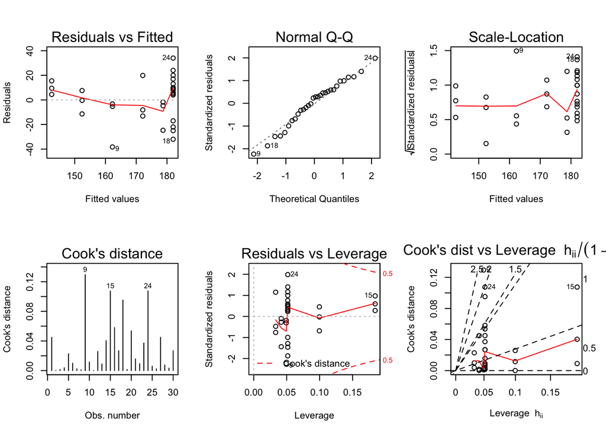

```r
m <- lm(Protein ~ cpfa, data = d)

opar = par(mfrow=c(2,3))
plot(m, 1:6, ask = FALSE)
```

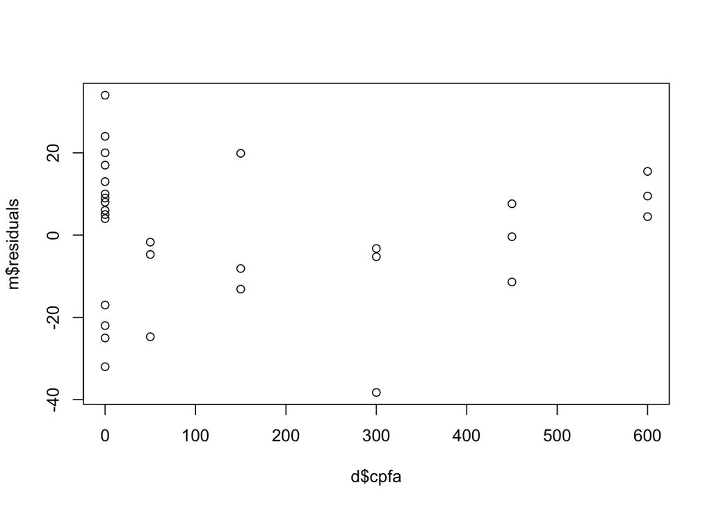

```r
par(opar)

plot(d$cpfa, m$residuals)
```